# Descriptive Analysis: The Netflix Effect on Local Housing Prices

Jayden Johnston and Lindsey Paulson

April 28, 2026

# Research Question

Do popular television shows raise housing prices in the counties where they are filmed? Following the premiere of *Yellowstone* in 2018, Gallatin County, Montana saw a sharp rise in home prices, tourism, and short-term rentals. This pattern is not unique: anecdotal reports surround *Breaking Bad* in Albuquerque, *Outer Banks* in Charleston, and *The White Lotus* in Maui. We test whether this “Netflix Effect” shows up systematically in housing data across six U.S. shows.

The question matters because filming-county housing markets directly affect affordability, local tax bases, and short-term rental policy. If media exposure is a meaningful driver of price growth, that has implications for land-use planning and rental regulation in places that host film and television production.

# Data

We use the FHFA County House Price Index (HPI), 2000–2024, rescaled so each county equals 100 in 2000. The panel covers 60,259 county-year observations across 2,414 counties, of which 6 are treated and 2,408 serve as controls. The treated counties are Gallatin (MT, *Yellowstone*, 2018), Bernalillo (NM, *Breaking Bad*, 2008), Maui (HI, *The White Lotus*, 2021), Fulton (GA, *Stranger Things*, 2016), Charleston (SC, *Outer Banks*, 2020), and Camden (MO, *Ozark*, 2017).

Treatment assignment was constructed from a hand-coded show–county–year mapping built from Wikipedia and IMDb. Full data sourcing, cleaning decisions, and supplementary Zillow rent and Inside Airbnb data are documented in the Stage 2 writeup.

# Methods

Because each show premiered in a different year, a simple before-and-after comparison within a single county cannot seperate the show’s effect from national housing trends such as the 2008 financial crisis or the 2020 pandemic. We therefore use a staggered difference-in-difference (DiD) design with two-way fixed effects, estimated on the full panel of 2,414 counties. The baseline model is:

$HPI_{i,t} = \alpha_i + \gamma_t + \beta \cdot Post_{i,t} + \varepsilon_{i,t}$

We estimate three specifications. **Model 1** is the baseline DiD on the HPI level. **Model 2** drops *Outer Banks* and *The White Lotus*, whose premieres overlap with the COVID-era housing boom, to test whether the result depends on those two cohorts. **Model 3** uses the annual percent change in HPI as the outcome, which checks whether any effect is a sudden jump at premiere or a gradual divergence in growth rates.

# Exploratory Analysis

Figure 1 shows HPI for each treated county from 2000–2024, with each show’s premiere marked by a dashed line. Five of six counties appreciate sharply, reaching 2024 values between about 250 (Fulton, GA) and 450 (Gallatin, MT). Bernalillo (Breaking Bad) is the exception — it tracks the national median the whole way. Most of the acceleration happens after 2018, which is both when the later shows aired and when the national housing boom started.

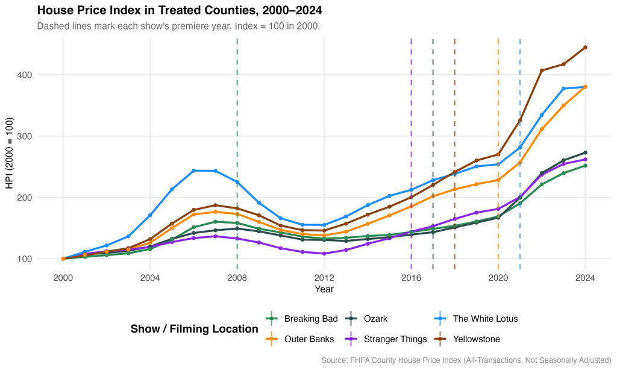

Figure 1. HPI trends in the six treated counties, with premiere years marked.

Figure 4 puts the treated counties next to the national median. Most of them sit well above the median by 2024, and the gap widens noticeably after 2018. A couple of the counties were already running above the national median before their shows aired.

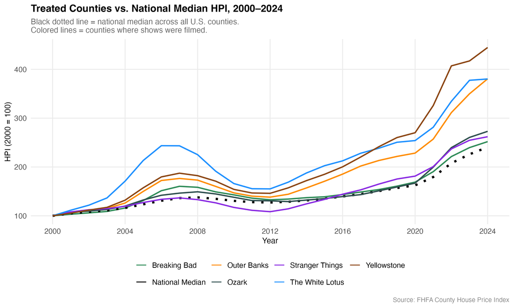

Figure 4. Treated counties vs. the national median HPI, 2000–2024.

# Regression Models

To quantify the pattern, I estimate a difference-in-differences regression with two-way fixed effects:

$$HPI_{it} = \alpha_i + \gamma_t + \beta
\cdot Post_{it} + \varepsilon_{it}$$

$\alpha_i$ is a county fixed effect (absorbs time-invariant differences between counties), $\gamma_t$ is a year fixed effect (absorbs national shocks), and $Post_{it} = 1$ for treated counties in years at or after their show’s premiere. $\beta$ is the coefficient of interest — the average change in HPI in treated counties after the premiere, net of the national year trend. Standard errors are clustered at the county level.

We also ran two robustness checks. **Model 2** drops *Outer Banks* and *The White Lotus* since their premieres overlap with the pandemic housing boom. **Model 3** uses the annual % change in HPI instead of the level.

# Results

| Outcome | $\hat{\beta}_{Post}$ | Std. Error | p-value |
| --- | --- | --- | --- |
| **(1)** HPI level, all shows | **41.68** | 17.22 | **0.016** |
| **(2)** HPI level, excl. COVID-era premieres | 33.00 | 21.61 | 0.127 |
| **(3)** Annual % change in HPI | 0.22 | 0.57 | 0.700 |

**Model 1** says treated counties’ HPI is about 42 points higher after their show premieres than their own pre-premiere level and the national trend would predict. On a 2000 base of 100, that’s roughly 42 percentage points of extra appreciation. Significant at the 5% level.

**Model 2** cuts the two COVID-era cohorts. The estimate drops to about 33 and loses significance (p = 0.127), so roughly a quarter of the headline effect is coming from those two shows. The rest is still positive.

**Model 3** uses growth rates instead of levels. The coefficient is basically zero (0.22, p = 0.70). This tells me the level gap isn’t from a sudden post-premiere jump — it builds up slowly, with treated counties appreciating a little faster each year.

One caveat visible in Figure 4: some treated counties were already on a higher-growth path before their shows aired. DiD assumes that wasn’t the case, so Model 1 probably overstates any real “Netflix effect.”

# Summary

Across six filming counties, treated areas appreciated faster than the rest of the U.S. after their shows aired, with a baseline DiD estimate of about 42 HPI points. Two tweaks affect this finding though. First, the effect weakens substantially when COVID-era premieres are excluded, suggesting the result is partly capturing the pandemic housing boom rather than a clean media effect. Second, the growth-rate specification tells us the gap grows gradually rather than right at premiere, which makes it harder to say for sure that a single show drives a discrete shock to local demand. Figure 4 also shows that some treated counties were on a higher-growth path before their shows aired, which violates DiD’s parallel-trends assumption and likely biases Model 1 upward.

Taken together, the evidence is consistent with a modest “Netflix Effect” in some counties, but a clean causal estimate would require a research design with stronger control over pre-existing trends.

# Challenge

Our challenge was **web scraping with `rvest`**, which we used to pull filming-location and premiere-year information from Wikipedia show pages to construct the treatment assignment. This went beyond the in-class material on `rvest` in two ways: we worked with infobox tables that required navigating nested HTML structure rather than flat tables, and we cross-validated the scraped premiere years against IMDb metadata to catch any differences. The resulting mapping is what links each show to its county and treatment year throughout the analysis.